# Homework 7 - Creating a resume database

Author

Nick Arthur

Published

November 9, 2023

In this homeowrk assignment, we are creating a ddl file and building a database from scratch using SQL. We have a high-level diagram for our schema, the list of tables, and some sample data.

GITHUB URL: https://github.com/cmsc-vcu/cmsc508-fa2023-hw7-ncarthur

## Overview and description

Ths database represents a company-wide resume capturing the collective skills and certifications of all the people in my company. The database captures skills, employees and their roles within the company. The database helps us find employees with specific skills, lists the skills of any employees and helps find gaps in the skill sets of employees in specific roles.

## Crows-foot diagram

A Crows-foot diagram of the database per the specification.

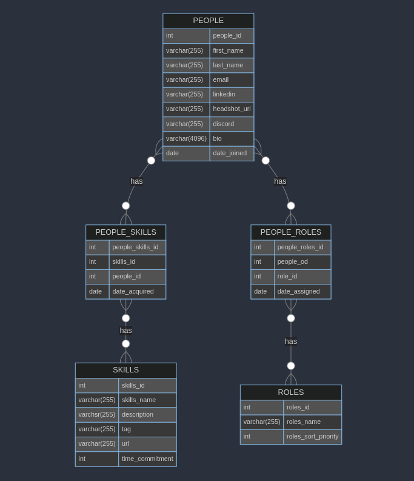

Crows-foot diagram

## Examples of data in the database

For the people, skills, and roles tables, provide a description of each table and it’s contents. Then provide a listing of the entire table.

### People table

The *people* table contains elements that describe people. A person has a name, a linkedin profile and a headshot.

Below is a list of data in the *people* table.

|  | people_id | people_first_name | people_last_name | people_email | people_linkedin_url | people_headshot_url | people_discord_handle | people_brief_bio | people_date_joined |
| --- | --- | --- | --- | --- | --- | --- | --- | --- | --- |
| 0 | 1 | John | Person 1 | john.smith@email.com | https://www.linkedin.com/in/johnsmith | https://example.com/johnsmith_headshot.jpg | JohnSmith#1234 | Software Engineer with 5 years of experience i... | 2023-01-15 |
| 1 | 2 | Sarah | Person 2 | sarah.johnson@email.com | https://www.linkedin.com/in/sarahjohnson | https://example.com/sarahjohnson_headshot.jpg | SarahJ#5678 | Marketing specialist passionate about digital ... | 2022-11-30 |
| 2 | 3 | Michael | Person 3 | michael.brown@email.com | https://www.linkedin.com/in/michaelbrown | https://example.com/michaelbrown_headshot.jpg | MBrown#9876 | Data scientist with expertise in machine learn... | 2023-02-10 |
| 3 | 4 | Emily | Person 4 | emily.davis@email.com | https://www.linkedin.com/in/emilydavis | https://example.com/emilydavis_headshot.jpg | EmilyD#6543 | Graphic designer with a passion for visual sto... | 2023-04-18 |
| 4 | 5 | David | Person 5 | david.wilson@email.com | https://www.linkedin.com/in/davidwilson | https://example.com/davidwilson_headshot.jpg | DavidW#3210 | Environmental scientist dedicated to sustainab... | 2022-09-07 |
| 5 | 6 | Olivia | Person 6 | olivia.anderson@email.com | https://www.linkedin.com/in/oliviaanderson | https://example.com/oliviaanderson_headshot.jpg | OliviaA#7890 | Journalist covering international affairs and ... | 2022-12-05 |
| 6 | 7 | James | Person 7 | james.miller@email.com | https://www.linkedin.com/in/jamesmiller | https://example.com/jamesmiller_headshot.jpg | JamesM#4567 | Financial analyst specializing in stock market... | 2023-03-20 |
| 7 | 8 | Sophia | Person 8 | sophia.robinson@email.com | https://www.linkedin.com/in/sophiarobinson | https://example.com/sophiarobinson_headshot.jpg | SophiaR#9876 | Educator passionate about innovative teaching ... | 2022-08-12 |
| 8 | 9 | Benjamin | Person 9 | benjamin.harris@email.com | https://www.linkedin.com/in/benjaminharris | https://example.com/benjaminharris_headshot.jpg | BenH#3333 | Architect with a focus on sustainable and eco-... | 2022-10-25 |
| 9 | 10 | Chloe | Person 10 | chloe.wright@email.com | https://www.linkedin.com/in/chloewright | https://example.com/chloewright_headshot.jpg | ChloeW#2222 | Entrepreneur and small business owner in the f... | 2023-05-15 |

### Skills table

The *skills* table contains elements that describe skills. Skills have a name, description, and a time required to aquire a particular skill.

Below is a list of data in the *skills* table.

|  | skills_id | skills_name | skills_description | skills_tag | skills_url | skills_time_commitment |
| --- | --- | --- | --- | --- | --- | --- |
| 0 | 1 | Coding | Programming in various languages | Skill 1 | https://example.com/skill1 | 20 |
| 1 | 2 | Graphic Design | Creating visually appealing graphics | Skill 2 | https://example.com/skill2 | 15 |
| 2 | 3 | Data Analysis | Analyzing data sets for insights | Skill 3 | https://example.com/skill3 | 25 |
| 3 | 4 | Digital Marketing | Promoting products online | Skill 4 | https://example.com/skill4 | 10 |
| 4 | 5 | Creative Writing | Writing imaginative content | Skill 5 | https://example.com/skill5 | 12 |
| 5 | 6 | Video Editing | Editing and producing videos | Skill 6 | https://example.com/skill6 | 18 |
| 6 | 7 | Project Management | Managing projects effectively | Skill 7 | https://example.com/skill7 | 30 |
| 7 | 8 | Public Speaking | Effective communication to an audience | Skill 8 | https://example.com/skill8 | 8 |

### Roles table

The *roles* table contains elements that describe various roles that employees have. An employee can have multiple roles, and multiple employees can have a single role.

Below is a list of data in the *roles* table.

|  | roles_id | roles_name | roles_sort_priority |
| --- | --- | --- | --- |
| 0 | 1 | Designer | 10 |
| 1 | 2 | Developer | 20 |
| 2 | 3 | Recruit | 30 |
| 3 | 4 | Team Lead | 40 |
| 4 | 5 | Boss | 50 |
| 5 | 6 | Mentor | 60 |

## Sample queries

Let’s explore the database!

# List skill names, tags, and descriptions ordered by name

Here is a sample query,

```python
sql = f"""
select * from skills ORDER BY skills_name;
"""
```

and here is a sample result from the query.

|  | skills_id | skills_name | skills_description | skills_tag | skills_url | skills_time_commitment |
| --- | --- | --- | --- | --- | --- | --- |
| 0 | 1 | Coding | Programming in various languages | Skill 1 | https://example.com/skill1 | 20 |
| 1 | 5 | Creative Writing | Writing imaginative content | Skill 5 | https://example.com/skill5 | 12 |
| 2 | 3 | Data Analysis | Analyzing data sets for insights | Skill 3 | https://example.com/skill3 | 25 |
| 3 | 4 | Digital Marketing | Promoting products online | Skill 4 | https://example.com/skill4 | 10 |
| 4 | 2 | Graphic Design | Creating visually appealing graphics | Skill 2 | https://example.com/skill2 | 15 |
| 5 | 7 | Project Management | Managing projects effectively | Skill 7 | https://example.com/skill7 | 30 |
| 6 | 8 | Public Speaking | Effective communication to an audience | Skill 8 | https://example.com/skill8 | 8 |
| 7 | 6 | Video Editing | Editing and producing videos | Skill 6 | https://example.com/skill6 | 18 |

### List people names and email addresses ordered by last_name

|  | people_first_name | people_last_name | people_email |
| --- | --- | --- | --- |
| 0 | John | Person 1 | john.smith@email.com |
| 1 | Chloe | Person 10 | chloe.wright@email.com |
| 2 | Sarah | Person 2 | sarah.johnson@email.com |
| 3 | Michael | Person 3 | michael.brown@email.com |
| 4 | Emily | Person 4 | emily.davis@email.com |
| 5 | David | Person 5 | david.wilson@email.com |
| 6 | Olivia | Person 6 | olivia.anderson@email.com |
| 7 | James | Person 7 | james.miller@email.com |
| 8 | Sophia | Person 8 | sophia.robinson@email.com |
| 9 | Benjamin | Person 9 | benjamin.harris@email.com |

### List skill names of Person 1

|  | skills_name |
| --- | --- |
| 0 | Coding |
| 1 | Data Analysis |
| 2 | Video Editing |

### List people names with Skill 6

|  | people_first_name | people_last_name |
| --- | --- | --- |
| 0 | John | Person 1 |
| 1 | David | Person 5 |
| 2 | James | Person 7 |
| 3 | Sophia | Person 8 |
| 4 | Benjamin | Person 9 |

### List people with a DEVELOPER role

|  | people_id | people_first_name | people_last_name | people_email | people_linkedin_url | people_headshot_url | people_discord_handle | people_brief_bio | people_date_joined | peopleroles_id | people_id | roles_id | roles_id | roles_name | roles_sort_priority |
| --- | --- | --- | --- | --- | --- | --- | --- | --- | --- | --- | --- | --- | --- | --- | --- |
| 0 | 1 | John | Person 1 | john.smith@email.com | https://www.linkedin.com/in/johnsmith | https://example.com/johnsmith_headshot.jpg | JohnSmith#1234 | Software Engineer with 5 years of experience i... | 2023-01-15 | 1 | 1 | 2 | 2 | Developer | 20 |
| 1 | 3 | Michael | Person 3 | michael.brown@email.com | https://www.linkedin.com/in/michaelbrown | https://example.com/michaelbrown_headshot.jpg | MBrown#9876 | Data scientist with expertise in machine learn... | 2023-02-10 | 4 | 3 | 2 | 2 | Developer | 20 |
| 2 | 6 | Olivia | Person 6 | olivia.anderson@email.com | https://www.linkedin.com/in/oliviaanderson | https://example.com/oliviaanderson_headshot.jpg | OliviaA#7890 | Journalist covering international affairs and ... | 2022-12-05 | 8 | 6 | 2 | 2 | Developer | 20 |
| 3 | 9 | Benjamin | Person 9 | benjamin.harris@email.com | https://www.linkedin.com/in/benjaminharris | https://example.com/benjaminharris_headshot.jpg | BenH#3333 | Architect with a focus on sustainable and eco-... | 2022-10-25 | 13 | 9 | 2 | 2 | Developer | 20 |
| 4 | 10 | Chloe | Person 10 | chloe.wright@email.com | https://www.linkedin.com/in/chloewright | https://example.com/chloewright_headshot.jpg | ChloeW#2222 | Entrepreneur and small business owner in the f... | 2023-05-15 | 14 | 10 | 2 | 2 | Developer | 20 |

### List names and email addresses of people without skills

|  | people_first_name | people_last_name | people_email |
| --- | --- | --- | --- |
| 0 | Emily | Person 4 | emily.davis@email.com |

### List names and tags of unused skills

|  | skills_name | skills_tag |
| --- | --- | --- |
| 0 | Project Management | Skill 7 |
| 1 | Public Speaking | Skill 8 |

### List people names and skill names with the BOSS role

|  | people_first_name | people_last_name | skills_name |
| --- | --- | --- | --- |
| 0 | Sarah | Person 2 | Data Analysis |
| 1 | Sarah | Person 2 | Digital Marketing |
| 2 | Sarah | Person 2 | Creative Writing |

### List ids and names of unused roles (there aren’t any)

|  | roles_id | roles_name |
| --- | --- | --- |

## Reflection

Building databases is extremely fun. It is very easy to get caught up in the notation and keywords for SQL. However, SQL is very intuitive and there are not many keywords and weird syntax things that need to be kept in mind. It is very easy to use. I had the most fun thinking about the different joins I had to perform on the tables to answer the questions. Besides one or two questions, I knew exactly the type of joins I needed to perform on the tables to get exactly what I was looking for. Playing with the tables and answering questions about the database are my favorite parts of the database-creation process.